# Congressional Voting Patterns

Jeff Shamp

2020-05-08

# Introduction

Is the net vote share won by Trump per district in 2016 predictive of a Senator’s voting record with regards to the Trump agenda? Is the predicted agreement (with Trump) value generated by 538.com *more* predictive of a Senator’s actual voting record?

538 updates a daily tally of who in congress supports President Trump by voting in alingment with his agenda. The also have built a prediction as to how frequently the Congressperson ‘should’ vote in alignment with President Trump based on various historical factors.

I like this idea becuase it takes the general voting trend of a given district or state as a proxy for how aligned that location is with President Trump’s agend. It makes for an interesting view into how well a member of Congress aligns with the voting record of their constituency vs. their alignment with Trump.

For my analysis, I will be focusing on the Senate and how members vote regarding Trump’s agenda.

# Data Overview

A link to the data can be found [here](https://projects.fivethirtyeight.com/congress-trump-score/).

These data come from an observational study of the voting patterns of Senators serving in Congress during the Trump administration. Agreement with the Trump agend is defined by which bills the President openly supports. There is no experiment conducted here, it is simple a record of how each Senator has voted. Each case is the current (as of 5/5/2020) total votes for Senator, their home state, party affiliation, the percent they vote in agreement with the Trump administration, their predicted agreement by 538, and the net share of the vote won by Trump in their district in 2016. The variables of interest here are numeric; percent agreement, predicted agreement, net Trump vote share. Analysis of predictors by party are categorical; Democrat and Republican. Independents are excluded form this analysis for two reasons; 1) there are only two of them, and 2) one independent has been running for president as a democrat since 2016.

Since this is data from a population and an observational study, this analysis only generalizes to the current population of Senators. Additionally, we cannot determine casuality from these predictors due the nature of the data collection.

```r
library(RCurl)
library(ggplot2)
library(dplyr)
```

```r
d<-getURL(
"https://raw.githubusercontent.com/Shampjeff/cuny_msds/master/DATA_607/data/averages.csv")
df<-read.csv(text=d, stringsAsFactors = FALSE)
senate_df<-subset(df, chamber=='senate' & congress==0)
senate_df<- subset(senate_df, select=-c(district,bioguide, chamber, congress))
senate_df$party[senate_df$party == "I"]<- "Independent"
senate_df$party[senate_df$party == "D"]<- "Democrat"
senate_df$party[senate_df$party == "R"]<-"Republican"
senate_df <- senate_df %>% filter(party != "Independent")
DT::datatable(senate_df,
              extensions = c('FixedColumns',"FixedHeader"),
              options = list(scrollX = TRUE,
                         paging=TRUE,
                         fixedHeader=TRUE,
                         pageLength=7))
```

|  | last_name | state | party | votes | agree_pct | predicted_agree | net_trump_vote |
| --- | --- | --- | --- | --- | --- | --- | --- |
| 1 | Alexander | TN | Republican | 113 | 0.902654867256637 | 0.86757791 | 26.0057009 |
| 2 | Blunt | MO | Republican | 120 | 0.933333333333333 | 0.80684347 | 18.637117 |
| 3 | Brown | OH | Democrat | 120 | 0.266666666666667 | 0.65865244 | 8.1295744 |
| 4 | Burr | NC | Republican | 115 | 0.921739130434783 | 0.57388186 | 3.65522853 |
| 5 | Baldwin | WI | Democrat | 120 | 0.233333333333333 | 0.52345513 | 0.7643432 |
| 6 | Boozman | AR | Republican | 121 | 0.942148760330578 | 0.87290983 | 26.92097803 |
| 7 | Blackburn | TN | Republican | 123 | 0.91869918699187 | 0.91250114 | 26.0057009 |
| 8 | Barrasso | WY | Republican | 121 | 0.917355371900826 | 0.91754858 | 46.29527573 |
| 9 | Bennet | CO | Democrat | 113 | 0.283185840707965 | 0.42823405 | -4.90558301 |
| 10 | Blumenthal | CT | Democrat | 120 | 0.208333333333333 | 0.30040163 | -13.63938672 |

[output cut: 103 more lines]

## Exploratory Data Analysis

As one might expect now the distribution is bimodal, there is a clear divide on agreement with Trump base on party affiliation.

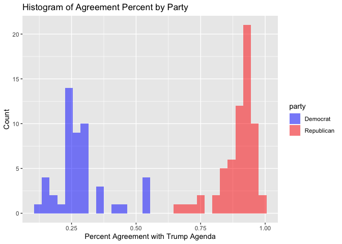

```r
senate_df %>%
  ggplot() +
  geom_histogram(aes(x=agree_pct, fill=party),
                 alpha=0.5,
                 binwidth = 0.03)+
  scale_fill_manual(values = c("blue", "red")) +
  labs(x="Percent Agreement with Trump Agenda",
       y="Count",
       title="Histogram of Agreement Percent by Party")
```

#### Mean Agreement Percent by Party

```r
by(senate_df$agree_pct, senate_df$party, mean)
```

```
## senate_df$party: Democrat
## [1] 0.2822639
## ------------------------------------------------------------
## senate_df$party: Republican
## [1] 0.89607
```

We see a similar pattern with predicted agreement. There is more overlap in the predicted agreement by party, but the mean value by party is (informally) different.

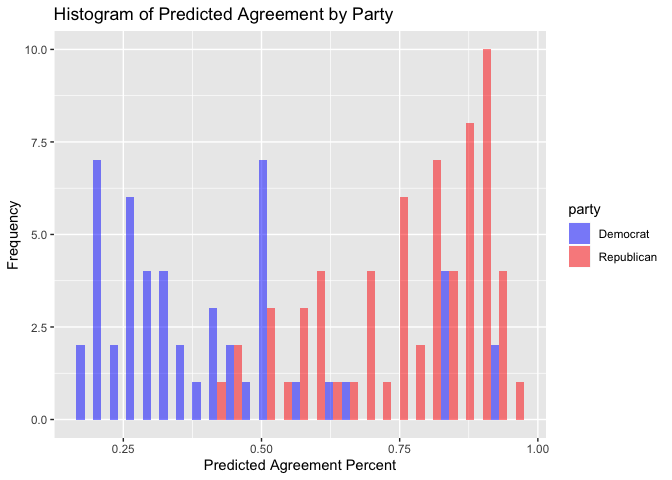

```r
senate_df %>%
  ggplot() +
  geom_histogram(aes(x=predicted_agree, fill=party),
                 position = "dodge",
                 alpha=0.5,
                 binwidth = .03) +
  scale_fill_manual(values = c("blue", "red")) +
  labs(x = "Predicted Agreement Percent",
       y="Frequency",
       title = "Histogram of Predicted Agreement by Party")
```

#### Mean Predicted Agreement by Party

```r
by(senate_df$predicted_agree, senate_df$party, mean)
```

```
## senate_df$party: Democrat
## [1] 0.417901
## ------------------------------------------------------------
## senate_df$party: Republican
## [1] 0.760461
```

And we see a similar overlap but with a different distribution for net vote won by Trump in 2016.

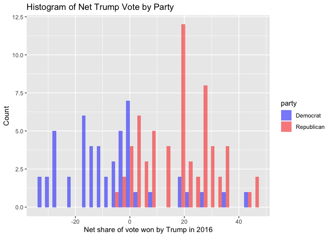

```r
senate_df %>%
  ggplot() +
  geom_histogram(aes(x=net_trump_vote, fill=party),
                 position = "dodge",
                 alpha=0.5, bins=30) +
  scale_fill_manual(values = c("blue", "red")) +
  labs(x = "Net share of vote won by Trump in 2016",
       y="Count",
       title = "Histogram of Net Trump Vote by Party")
```

#### Mean Net Trump Vote by Party

```r
by(senate_df$net_trump_vote, senate_df$party, mean)
```

```
## senate_df$party: Democrat
## [1] -7.261428
## ------------------------------------------------------------
## senate_df$party: Republican
## [1] 18.16908
```

#### Summary for Democrats

```r
summary((senate_df%>%
           filter(party=="Democrat") %>%
           select(votes,
                  agree_pct,
                  predicted_agree,
                  net_trump_vote)))
```

```
##      votes         agree_pct      predicted_agree  net_trump_vote
##  Min.   : 55.0   Min.   :0.1239   Min.   :0.1937   Min.   :-32.18281
##  1st Qu.:113.8   1st Qu.:0.2356   1st Qu.:0.2747   1st Qu.:-16.67485
##  Median :120.0   Median :0.2596   Median :0.3484   Median : -9.59554
##  Mean   :112.9   Mean   :0.2823   Mean   :0.4179   Mean   : -7.26143
##  3rd Qu.:121.0   3rd Qu.:0.3043   3rd Qu.:0.5091   3rd Qu.:  0.07536
##  Max.   :128.0   Max.   :0.5476   Max.   :0.9152   Max.   : 42.15365
```

#### Summary for Republicans

```r
summary((senate_df%>%
           filter(party=="Republican") %>%
           select(votes,
                  agree_pct,
                  predicted_agree,
                  net_trump_vote)))
```

```
##      votes         agree_pct      predicted_agree  net_trump_vote
##  Min.   :  7.0   Min.   :0.6694   Min.   :0.4179   Min.   :-4.906
##  1st Qu.: 99.5   1st Qu.:0.8755   1st Qu.:0.6678   1st Qu.: 6.644
##  Median :119.0   Median :0.9167   Median :0.8068   Median :18.637
##  Mean   :101.8   Mean   :0.8961   Mean   :0.7605   Mean   :18.169
##  3rd Qu.:121.0   3rd Qu.:0.9378   3rd Qu.:0.8807   3rd Qu.:27.323
##  Max.   :133.0   Max.   :1.0000   Max.   :0.9576   Max.   :46.295
```

When plotting the predictive variables we again see a separation between the independent and dependent variables base on party.

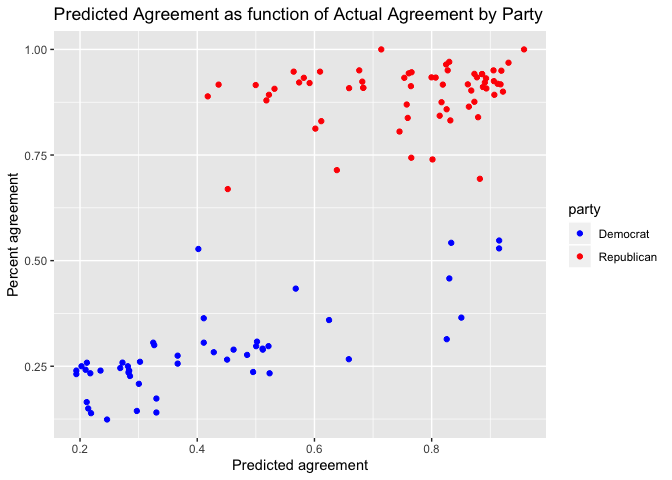

```r
senate_df %>%
  ggplot() +
  geom_point(aes(y=agree_pct,
             x=predicted_agree,
             color=party)) +
  scale_color_manual(values = c("blue", "red")) +
  labs(y="Percent agreement",
       x="Predicted agreement",
       title="Predicted Agreement as function of Actual Agreement by Party")
```

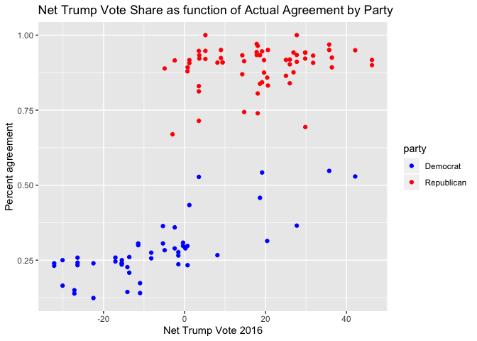

```r
senate_df %>%
  ggplot() +
  geom_point(aes(x=net_trump_vote,
             y=agree_pct,
             color=party)) +
  scale_color_manual(values = c("blue", "red")) +
  labs(y="Percent agreement",
       x="Net Trump Vote 2016",
       title="Net Trump Vote Share as function of Actual Agreement by Party")
```

## Implications of Data Analysis

We see that agreement percent with the president is clearly separable by party. There is no overlap in agreement based on party. There appears to a separation between the predicted agreement score generated by 538 based on party, and we can test to verify if those means are different. This is also true for the net share of the vote won by Trump in 2016.

Given the distributions in the data for the entire Senate do not appear to be nearly normal, but could potential meet the requirements of normality if considered separately by party. We will first attempt to show a theoretical separation in mean base on party affiliation. If the mean values for these variables are different, then we will consider party affiliation separately for predictive power.

# Inference for Mean Values

We will start by checking for normality for the predicted agreement score and net Trump vote share.

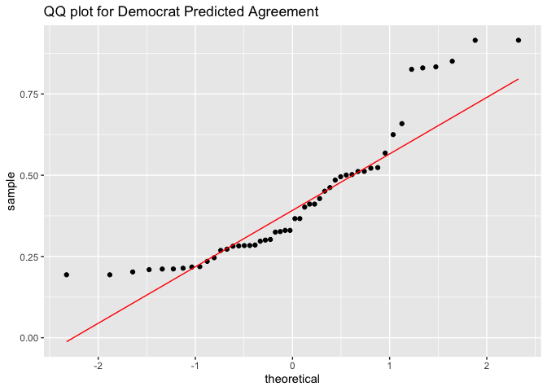

```r
senate_df %>%
  filter(party == "Democrat") %>%
  select(predicted_agree) %>%
  ggplot(aes(sample = predicted_agree)) +
  stat_qq() +
  stat_qq_line(color="red") +
  labs(title="QQ plot for Democrat Predicted Agreement")
```

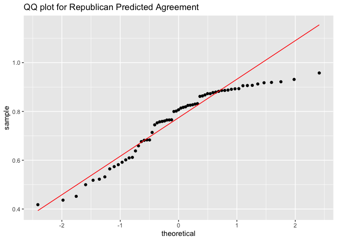

```r
senate_df %>%
  filter(party == "Republican") %>%
  select(predicted_agree) %>%
  ggplot(aes(sample = predicted_agree)) +
  stat_qq() +
  stat_qq_line(color="red") +
  labs(title="QQ plot for Republican Predicted Agreement")
```

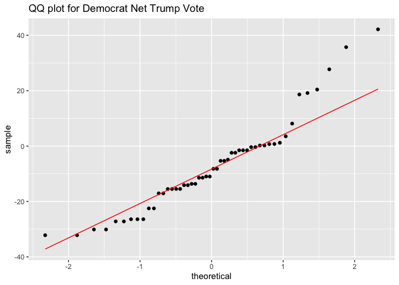

```r
senate_df %>%
  filter(party == "Democrat") %>%
  select(net_trump_vote) %>%
  ggplot(aes(sample = net_trump_vote)) +
  stat_qq() +
  stat_qq_line(color="red") +
  labs(title="QQ plot for Democrat Net Trump Vote")
```

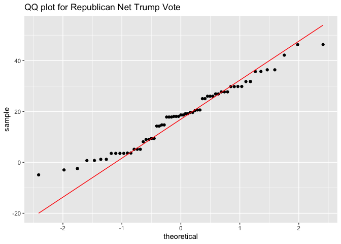

```r
senate_df %>%
  filter(party == "Republican") %>%
  select(net_trump_vote) %>%
  ggplot(aes(sample = net_trump_vote)) +
  stat_qq() +
  stat_qq_line(color="red") +
  labs(title="QQ plot for Republican Net Trump Vote")
```

With some lifted tails beyond $Z \pm 1$ there is some concern about normality for the predicted agreement score for Democrates. Possibily due to an outlier.

Let’s look at a two mean test for predicited agreement based on political party.

```r
DATA606::inference(y = senate_df$predicted_agree,
                   x = senate_df$party, est = "mean",
                   type = "ht", null = 0,
                   alternative = "twosided", method = "theoretical")
```

```
## Response variable: numerical, Explanatory variable: categorical
## Difference between two means
## Summary statistics:
## n_Democrat = 50, mean_Democrat = 0.4179, sd_Democrat = 0.2048
## n_Republican = 63, mean_Republican = 0.7605, sd_Republican = 0.1436
```

```
## Observed difference between means (Democrat-Republican) = -0.3426
##
## H0: mu_Democrat - mu_Republican = 0
## HA: mu_Democrat - mu_Republican != 0
## Standard error = 0.034
## Test statistic: Z =  -10.033
## p-value =  0
```

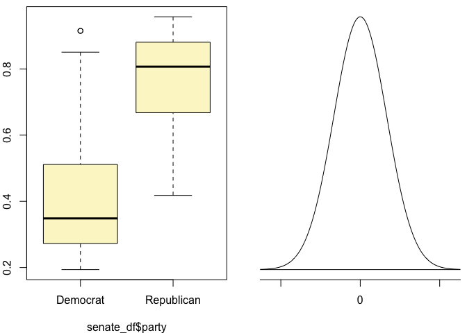

While there is an outlier in the democratic party, we see that the difference in the mean predicted agreement with Trump is not due to chance.

```r
DATA606::inference(y = senate_df$net_trump_vote,
                   x = senate_df$party, est = "mean",
                   type = "ht", null = 0,
                   alternative = "twosided", method = "theoretical")
```

```
## Response variable: numerical, Explanatory variable: categorical
## Difference between two means
## Summary statistics:
## n_Democrat = 50, mean_Democrat = -7.2614, sd_Democrat = 16.8527
## n_Republican = 63, mean_Republican = 18.1691, sd_Republican = 12.6541
```

```
## Observed difference between means (Democrat-Republican) = -25.4305
##
## H0: mu_Democrat - mu_Republican = 0
## HA: mu_Democrat - mu_Republican != 0
## Standard error = 2.867
## Test statistic: Z =  -8.869
## p-value =  0
```

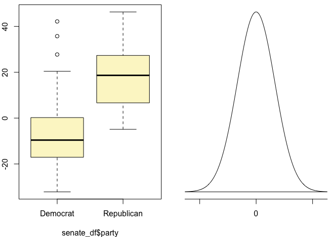

Again, we see a similar story, as expected. There is strong evidence that the mean share of the vote won by Trump in 2016 is different based on senator political party.

We will consider the parties separately moving forward.

# Inference for Predictive Variables

Now that we have seen the qqplots and distributions for the predictors by political party we will analyze the predictive power of each variable.

## Predicted Agreement Score - Democrats

We will start with the predicted agreement score generated by 538 as a function of actual agreement via voting record. To do this, we will fit a linear model and assess it’s fit. We will pay close attention to the conditions of inference; *linearity, constant variance, nearly normal residuals*.

Let’s start with a linear model and plot of agreement percent as a function of predicted score for each party separately. We will also show the model diagnostics below.

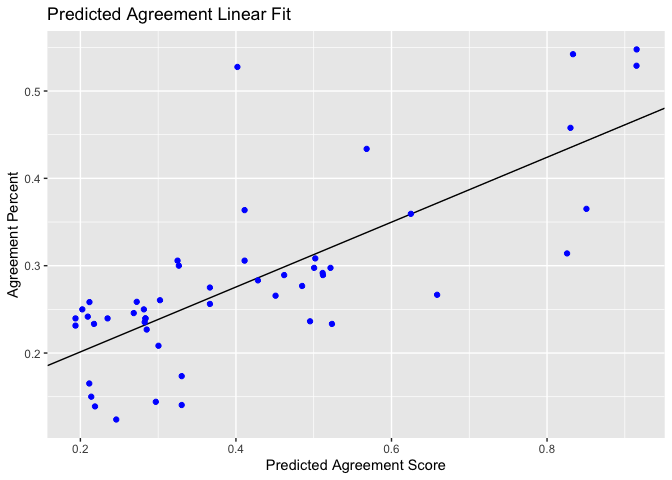

```r
senate_dem<- senate_df %>%
  filter(party == "Democrat")
dem_lin_reg<- lm(data=senate_dem, agree_pct ~ predicted_agree)

senate_df %>%
  filter(party =="Democrat") %>%
  select(predicted_agree, agree_pct) %>%
  ggplot(aes(x=predicted_agree, y=agree_pct)) +
  geom_abline(slope= dem_lin_reg$coefficients[2],
              intercept = dem_lin_reg$coefficients[1]) +
  geom_point(color="blue") +
  labs(x="Predicted Agreement Score",
       y="Agreement Percent",
       title="Predicted Agreement Linear Fit")
```

```r
summary(dem_lin_reg)
```

```
##
## Call:
## lm(formula = agree_pct ~ predicted_agree, data = senate_dem)
##
## Residuals:
##       Min        1Q    Median        3Q       Max
## -0.119727 -0.030393  0.001735  0.031922  0.251249
##
## Coefficients:
##                 Estimate Std. Error t value Pr(>|t|)
## (Intercept)      0.12701    0.02172   5.848 4.28e-07 ***
## predicted_agree  0.37152    0.04676   7.945 2.67e-10 ***
## ---
## Signif. codes:  0 '***' 0.001 '**' 0.01 '*' 0.05 '.' 0.1 ' ' 1
##
## Residual standard error: 0.06703 on 48 degrees of freedom
## Multiple R-squared:  0.568,  Adjusted R-squared:  0.559
## F-statistic: 63.12 on 1 and 48 DF,  p-value: 2.667e-10
```

Now we assess the residuals for linearity and normal distribution.

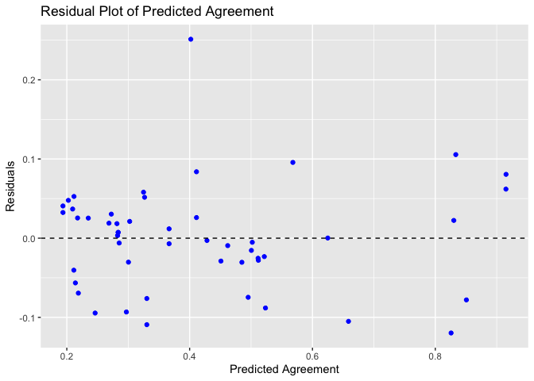

```r
senate_dem %>%
  ggplot() +
  geom_point(aes(x=predicted_agree,
                 y=dem_lin_reg$residuals),
             color="blue") +
  geom_hline(yintercept = 0,
             linetype="dashed") +
  labs(x="Predicted Agreement",
       y="Residuals",
       title="Residual Plot of Predicted Agreement")
```

We see there is an outlier at x=0.4, but these residual seem to be fairly well distributed around zero. There is also good indication of constant variance in the data as well. Let’s also check the distribution.

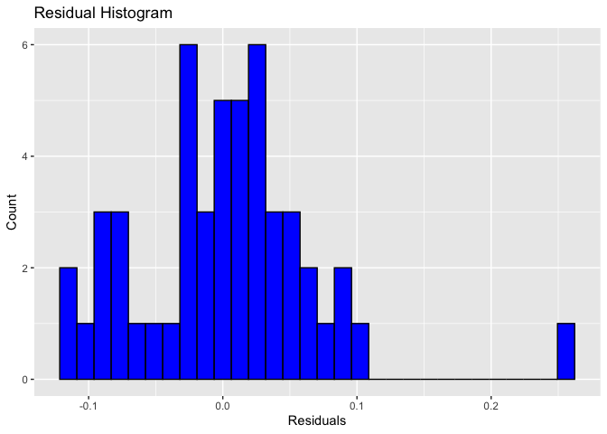

```r
ggplot(data = dem_lin_reg, aes(x=dem_lin_reg$residuals)) +
  geom_histogram(fill = "blue", color="black") +
  labs(x="Residuals", y="Count",
       title="Residual Histogram")
```

Again, outside of one outlier, this appears to be nearly normal.

## Summary of Predicted Agreement Score - Democrats

With the conditions for infernce met we see that the slope of the line for agreement percent as a function of predicted agreement by 538 is non-zero with p-value nearly zero (2.67e-10). The model can explain 56% of the variance in the data for democrats.

## Predicted Agreement Score - Republicans

We will take a similar route with Republicans.

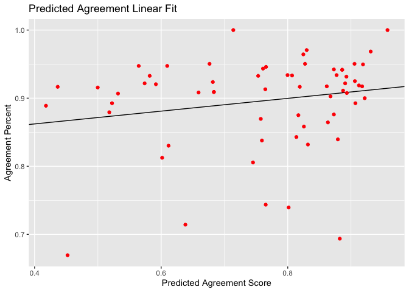

```r
senate_rep<- senate_df %>%
  filter(party == "Republican")
rep_lin_reg<- lm(data=senate_rep, agree_pct ~ predicted_agree)

senate_df %>%
  filter(party =="Republican") %>%
  select(predicted_agree, agree_pct) %>%
  ggplot(aes(x=predicted_agree, y=agree_pct)) +
  geom_abline(slope= rep_lin_reg$coefficients[2],
              intercept = rep_lin_reg$coefficients[1]) +
  geom_point(color="red") +
  labs(x="Predicted Agreement Score",
       y="Agreement Percent",
       title="Predicted Agreement Linear Fit")
```

```r
summary(rep_lin_reg)
```

```
##
## Call:
## lm(formula = agree_pct ~ predicted_agree, data = senate_rep)
##
## Residuals:
##      Min       1Q   Median       3Q      Max
## -0.21383 -0.02629  0.02028  0.04048  0.10830
##
## Coefficients:
##                 Estimate Std. Error t value Pr(>|t|)
## (Intercept)      0.82458    0.04636  17.785   <2e-16 ***
## predicted_agree  0.09401    0.05993   1.569    0.122
## ---
## Signif. codes:  0 '***' 0.001 '**' 0.01 '*' 0.05 '.' 0.1 ' ' 1
##
## Residual standard error: 0.06774 on 61 degrees of freedom
## Multiple R-squared:  0.03878,    Adjusted R-squared:  0.02302
## F-statistic: 2.461 on 1 and 61 DF,  p-value: 0.1219
```

Now we assess the residuals for linearity and normal distribution.

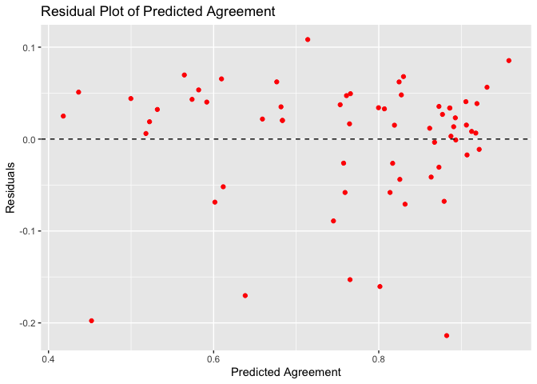

```r
senate_rep %>%
  ggplot() +
  geom_point(aes(x=predicted_agree,
                 y=rep_lin_reg$residuals),
             color="red") +
  geom_hline(yintercept = 0,
             linetype="dashed") +
  labs(x="Predicted Agreement",
       y="Residuals",
       title="Residual Plot of Predicted Agreement")
```

This do not appear to be too well distributed around zero with many points far below the y=0 line. There does appear to be constant variance.

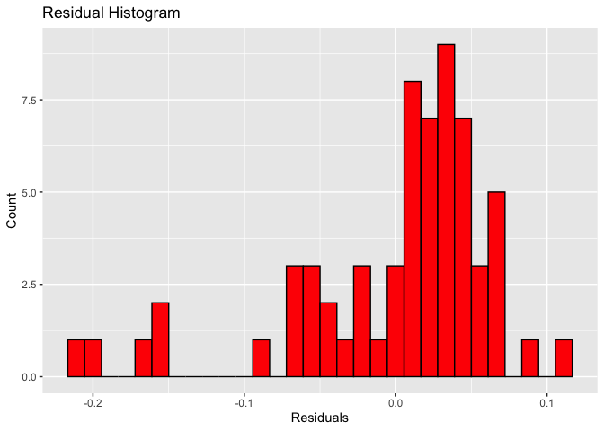

```r
ggplot(data = rep_lin_reg, aes(x=rep_lin_reg$residuals)) +
  geom_histogram(fill = "red", color="black") +
  labs(x="Residuals", y="Count",
       title="Residual Histogram")
```

Again, several points below x=0 on the residual histogram indicate a left-skewed distribution.

## Summary of Predicted Agreement Score - Republicans

With conditions reasonably met for a reliable model we see that predicted agreement as generated by 538 for Republicans fails to reject the null hypothesis for a non-zero slope with p-value= 0.122. The predicted agreement score is *not* predictive for how a Republican will vote in alignment with the Trump Agenda.

## Net Trump Vote - Democrats

We now turn out focus to if the net share of the vote won by Trump in 2016 is predictive of that senators voting record on the Trump agenda.

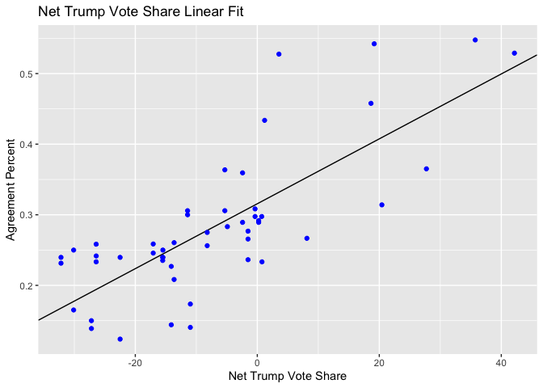

```r
senate_dem<- senate_df %>%
  filter(party == "Democrat")
dem_lin_reg<- lm(data=senate_dem, agree_pct ~ net_trump_vote)

senate_df %>%
  filter(party =="Democrat") %>%
  select(net_trump_vote, agree_pct) %>%
  ggplot(aes(x=net_trump_vote, y=agree_pct)) +
  geom_abline(slope= dem_lin_reg$coefficients[2],
              intercept = dem_lin_reg$coefficients[1]) +
  geom_point(color="blue") +
  labs(x="Net Trump Vote Share",
       y="Agreement Percent",
       title="Net Trump Vote Share Linear Fit")
```

```r
summary(dem_lin_reg)
```

```
##
## Call:
## lm(formula = agree_pct ~ net_trump_vote, data = senate_dem)
##
## Residuals:
##       Min        1Q    Median        3Q       Max
## -0.124683 -0.038430 -0.005219  0.041798  0.195612
##
## Coefficients:
##                 Estimate Std. Error t value Pr(>|t|)
## (Intercept)    0.3156469  0.0100813  31.310  < 2e-16 ***
## net_trump_vote 0.0045973  0.0005541   8.297 7.85e-11 ***
## ---
## Signif. codes:  0 '***' 0.001 '**' 0.01 '*' 0.05 '.' 0.1 ' ' 1
##
## Residual standard error: 0.06536 on 48 degrees of freedom
## Multiple R-squared:  0.5892, Adjusted R-squared:  0.5806
## F-statistic: 68.85 on 1 and 48 DF,  p-value: 7.854e-11
```

Now we assess the residuals for linearity and normal distribution.

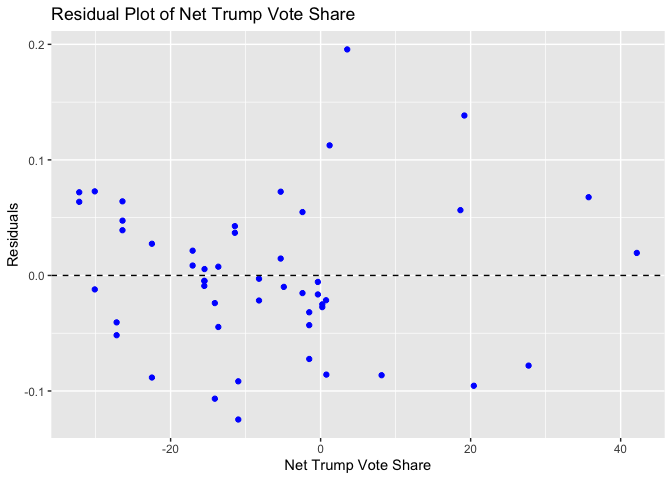

```r
senate_dem %>%
  ggplot() +
  geom_point(aes(x=net_trump_vote,
                 y=dem_lin_reg$residuals),
             color="blue") +
  geom_hline(yintercept = 0,
             linetype="dashed") +
  labs(x="Net Trump Vote Share",
       y="Residuals",
       title="Residual Plot of Net Trump Vote Share")
```

We see there is an outlier near 0% vote share, but these residual seem to be fairly well distributed around zero. There is also good indication of constant variance in the data as well. Let’s also check the distribution.

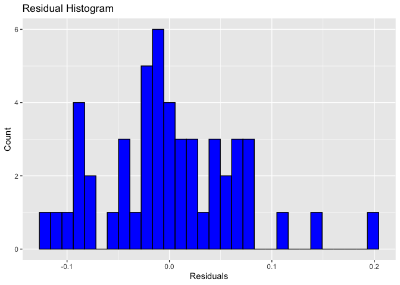

```r
ggplot(data = dem_lin_reg, aes(x=dem_lin_reg$residuals)) +
  geom_histogram(fill = "blue", color="black") +
  labs(x="Residuals", y="Count",
       title="Residual Histogram")
```

These appear to be nearly normal with some reservations about the distribution of the residuals. Again, a few outliers skewing the data to the right.

## Summary of Net Trump Vote Share - Democrats

Conditions for infernce are met and we see that the slope of the line for agreement percent as a function of net Trump vote share form 2016 is non-zero with p-value nearly zero (7.85e-11). The model can explain 59% of the variance in the data for democrats. This would make it a better predictor (by a small degree) than the predicted agreement generated by 538.

## Net Trump Vote - Republicans

We now turn out focus to if the net share of the vote won by Trump in 2016 is predictive of that senators voting record on the Trump agenda.

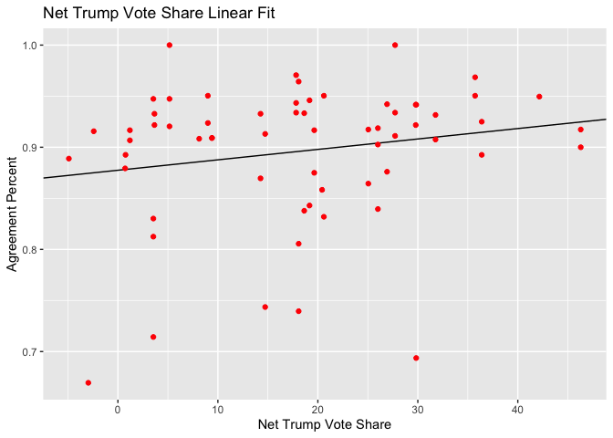

```r
senate_rep<- senate_df %>%
  filter(party == "Republican")
rep_lin_reg<- lm(data=senate_rep, agree_pct ~ net_trump_vote)

senate_df %>%
  filter(party =="Republican") %>%
  select(net_trump_vote, agree_pct) %>%
  ggplot(aes(x=net_trump_vote, y=agree_pct)) +
  geom_abline(slope= rep_lin_reg$coefficients[2],
              intercept = rep_lin_reg$coefficients[1]) +
  geom_point(color="red") +
  labs(x="Net Trump Vote Share",
       y="Agreement Percent",
       title="Net Trump Vote Share Linear Fit")
```

```r
summary(rep_lin_reg)
```

```
##
## Call:
## lm(formula = agree_pct ~ net_trump_vote, data = senate_rep)
##
## Residuals:
##      Min       1Q   Median       3Q      Max
## -0.21430 -0.02370  0.02049  0.03805  0.11723
##
## Coefficients:
##                Estimate Std. Error t value Pr(>|t|)
## (Intercept)    0.877498   0.015040  58.346   <2e-16 ***
## net_trump_vote 0.001022   0.000681   1.501    0.139
## ---
## Signif. codes:  0 '***' 0.001 '**' 0.01 '*' 0.05 '.' 0.1 ' ' 1
##
## Residual standard error: 0.06786 on 61 degrees of freedom
## Multiple R-squared:  0.03562,    Adjusted R-squared:  0.01981
## F-statistic: 2.253 on 1 and 61 DF,  p-value: 0.1385
```

Now we assess the residuals for linearity and normal distribution.

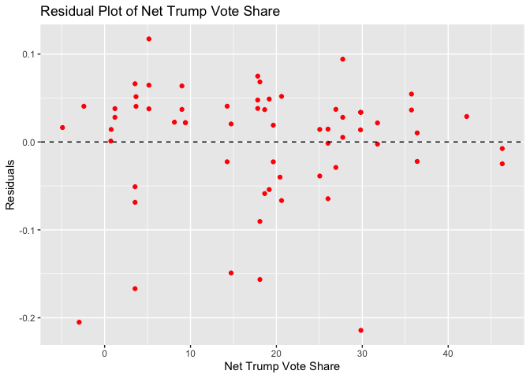

```r
senate_rep %>%
  ggplot() +
  geom_point(aes(x=net_trump_vote,
                 y=rep_lin_reg$residuals),
             color="red") +
  geom_hline(yintercept = 0,
             linetype="dashed") +
  labs(x="Net Trump Vote Share",
       y="Residuals",
       title="Residual Plot of Net Trump Vote Share")
```

## Summary of Net Trump Vote Share - Republicans

Conditions for infernce are met and we see that agreement percent as a function of net Trump vote share form 2016 fails to reject the null hypothesis for a non-zero slope with p-value=0.139. This is *not* a predictor for how a Republican will vote in alignment with the Trump agenda.

# Conclusion

I was surprised by these results, but it seems to make sense to some extent. Net vote share and 538 predicted score are not predictors of how a Reoublican will vote alongside Trump. This suggests that for Senators in states that Trump lost or only marginally won, Republicans still will vote largely in alignment with Trump. This seems counter to the standard rules of political self-interest but clearly there must a some other factor that out-weighs voting margins or historical data. Democrats appear to have more freedom in how they vote, though they all seem to cap their agreement with the Trump agenda to under 60%.

One avenue of future work would be to revisit the predicted score generated by 538. It does not appear to be a predictor for Republicans and is (marginally) worse predictor for Democrats when compared to net vote share. Or simply use or find new potential predictors. Maybe if there is some way to assess the primary voters in each state that might shed some insight into what motivates a Senator. Or who their major donors are and by what percent. It would be interesting to if percent of the state’s population that votes in the primary or percent of the a Senator’s campaign funding that comes from a single source (or classes of sources) are better predictors.